# CIND 123 - Data Analytics: Basic Methods

Stephanie Boissonneault

# Assignment 1 (10%)

# Instructions

Use RStudio for this assignment. Complete the assignment by inserting your code wherever you see the string “#INSERT YOUR ANSWER HERE”.

**NOTE**: YOU SHOULD NEVER HAVE `install.packages` IN YOUR CODE; OTHERWISE, THE `Knit` OPTION WILL GIVE AN ERROR. COMMENT OUT ALL PACKAGE INSTALLATIONS.

Submit **both** the `rmd` and generated `output` files. Failing to submit both files will be subject to mark deduction. PDF or HTML is preferred.

## Sample Question and Solution

Use `seq()` to create the vector $(3,5\ldots,29)$.

```r
seq(3, 30, 2)
```

```
##  [1]  3  5  7  9 11 13 15 17 19 21 23 25 27 29
```

```r
seq(3, 29, 2)
```

```
##  [1]  3  5  7  9 11 13 15 17 19 21 23 25 27 29
```

## Question 1 (32 points)

## Q1a (8 points)

Create and print a vector `x` with all integers from 4 to 115 and a vector `y` containing multiples of 4 in the same range. Hint: use `seq()`function. Calculate the difference in lengths of the vectors `x` and `y`. Hint: use length()

```r
x <- 4:115
x
```

```
##   [1]   4   5   6   7   8   9  10  11  12  13  14  15  16  17  18  19  20  21
##  [19]  22  23  24  25  26  27  28  29  30  31  32  33  34  35  36  37  38  39
##  [37]  40  41  42  43  44  45  46  47  48  49  50  51  52  53  54  55  56  57
##  [55]  58  59  60  61  62  63  64  65  66  67  68  69  70  71  72  73  74  75
##  [73]  76  77  78  79  80  81  82  83  84  85  86  87  88  89  90  91  92  93
##  [91]  94  95  96  97  98  99 100 101 102 103 104 105 106 107 108 109 110 111
## [109] 112 113 114 115
```

```r
y <- seq(from = 4, to = 115, by = 4)
y
```

```
##  [1]   4   8  12  16  20  24  28  32  36  40  44  48  52  56  60  64  68  72  76
## [20]  80  84  88  92  96 100 104 108 112
```

```r
#Difference in length
length(x)-length(y)
```

```
## [1] 84
```

## Q1b (8 points)

Create a new vector, `y_square`, with the square of elements at indices 1, 3, 7, 12, 17, 20, 22, and 24 from the variable `y`. Hint: Use indexing rather than a `for` loop. Calculate the mean and median of the FIRST five values from `y_square`.

```r
y_square <- y[c(1, 3, 7, 12, 17, 20, 22, 24)]**2
y_square
```

```
## [1]   16  144  784 2304 4624 6400 7744 9216
```

```r
mean(y_square[1:5])
```

```
## [1] 1574.4
```

```r
median(y_square[1:5])
```

```
## [1] 784
```

## Q1c (8 points)

For a given factor variable of `factorVar <- factor(c(1, 6, 5.4, 3.2))`, would it be correct to use the following commands to convert factor to number?

`as.numeric(factorVar)`

If not, explain your answer and provide the correct one.

```r
# When assigning a numeric vector into a factor variable, the factor will first recognize the different levels of the variables. In this case, there are four levels and they are recognized as 1, 3.2, 5.4, and 6.
factorVar <- factor(c(1, 6, 5.4, 3.2))
factorVar
```

```
## [1] 1   6   5.4 3.2
## Levels: 1 3.2 5.4 6
```

```r
#The factor internally assigns an integer number starting from 1 to each corresponding category in the level. In this case, 1 is the internal level of 1, 3.2 is the internal level 2, 5.4 is the internal level 3, and 6 is the internal level 4.

#Because these values are now internally assigned a number corresponding to their level, the as.numeric() function will convert the factor to a numeric class, but it will display the numbers corresponding to each value's internal level:

numericVar <- as.numeric(factorVar)
numericVar
```

```
## [1] 1 4 3 2
```

```r
class(numericVar)
```

```
## [1] "numeric"
```

```r
#To display the factor variable as numeric variables, we would need to first convert the factor to a character vector, followed by a numeric vector to ensure that the original numeric values are displayed rather than their associated internal level.

numericVar2 <- as.numeric(as.character(factorVar))
numericVar2
```

```
## [1] 1.0 6.0 5.4 3.2
```

```r
class(numericVar2)
```

```
## [1] "numeric"
```

## Q1d (8 points)

A comma-separated values file `dataset.csv` consists of missing values represented by Not A Number (`null`) and question mark (`?`). How can you read this type of files in R? NOTE: Please make sure you have saved the `dataset.csv` file at your current working directory.

```r
#I would set the header to false because the first row of the dataset has no header, and if "null" and "?" both represent missing values (rather than NULL or nothing), I would read these as NA strings using the following command:

dataset <- read.csv("dataset.csv", sep = ",", header = FALSE, stringsAsFactor = FALSE, na.strings= c("null", "?"))

dataset
```

```
##     V1  V2  V3  V4  V5  V6  V7  V8  V9 V10
## 1    1   2   3   4   5   6   7   8   9  10
## 2   11  12  13  14  15  16  17  18  19  20
## 3   21  22  23  24  25  26  27  28  29  30
## 4   31  32  33  34  35  36  37  38  39  40
## 5   41  42  43  44  45  NA  47  48  49  50
## 6   51  52  53  NA  55  56  57  NA  59  60
## 7   61  62  63  64  65  66  67  68  69  70
## 8   71  72  NA  74  75  76  77  78  79  80
## 9   81  82  83  84  85  86  87  88  89  NA
## 10  91  92  93  94  95  96  97  98  99 100
## 11  NA 102 103 104 105 106 107 108 109 110
## 12 111 112 113 114 115 116 117 118 119 120
## 13 121 122 123 124 125 126 127 128 129 130
## 14 131 132 133 134 135 136 137 138 139  NA
## 15 141 142 143 144 145 146 147 148 149 150
## 16 151 152 153 154 155 156 157 158 159 160
## 17 161 162 163 164  NA 166 167 168 169 170
```

# Question 2 (32 points)

## Q2a (8 points)

Compute:
$$\sum_{n=5}^{20}\frac{(-1)^{n}}{(n!)^2}$$
Hint: Use `factorial(n)` to compute $n!$.

```r
sum_function <- function(n){
            return(sum((-1)**n / factorial(n)**2))
            }
sum_function(5:20)
```

```
## [1] -6.755419e-05
```

## Q2b (8 points)

Compute:
$$\prod_{n=1}^{5} \left( 4n +
\frac{1}{2^n} \right)$$
NOTE: The symbol $\Pi$ represents multiplication.

```r
prod_function <- function(n) {
           return(prod(4*n + (1/(2**n))))
            }
prod_function(1:5)
```

```
## [1] 144833.6
```

## Q2c (8 points)

Describe what the following R command does: `c(0:5)[NA]`

```r
c(0:5)[NA]
```

```
## [1] NA NA NA NA NA NA
```

```r
#This command is asking R to conduct indexing on a vector made of a sequence of numbers between 0 to 5 (0, 1, 2, 3, 4, 5). The square brackets is an indexing tool and is used to extract a value from the vector. Normally, we indicate a number inside of the square brackets that corresponds with the position of the element we would like to extract from the vector.In this case, we are asking R to extract NA. NA represents a missing value. If we try to extract a missing value from the vector, the output for each value of the vector is also displayed as a missing value... This is because the indexing variable, NA, is missing from the vector.
```

## Q2d (8 points)

Describe the purpose of `is.vector()`, `is.character()`, `is.numeric()`, and `is.na()` functions? Please use `x <- c("a", "b", NA, 2)` to explain your description.

```r
x <- c("a", "b", NA, 2)

#The is.vector() function evaluates the object to let us know whether it is a vector and will returns a boolean value of (either True or False). In this example, the value returned is True because x is a single object containing the vector c("a", "b", NA, 2).
is.vector(x)
```

```
## [1] TRUE
```

```r
#The is.character function evaluates whether an object contains the character data type as either True or False. In this example, the function returned boolean value T because the object x contains the characters "a" and "b" because they are in quotation marks.
is.character(x)
```

```
## [1] TRUE
```

```r
#The is.numeric function returns the logical value of True when the object in question contains values of the numeric datatype (integers and float numbers). Otherwise the function will return False. In this example, is.numeric(x) returned False because vectors in R must contain values of the same data type. Thus, combining the numeric value of 2 with the character types "a" and "b" in a vector caused R to convert all items in that vector to the character type. Now, when I print x, the number 2 appears in quotation marks indicating that it is now a string. This can also be verified using the class() function as follows:
is.numeric(x)
```

```
## [1] FALSE
```

```r
x
```

```
## [1] "a" "b" NA  "2"
```

```r
class(x)
```

```
## [1] "character"
```

```r
#The is.na() function returns True or False based on the respective position of present or missing values. In this example, the object x contains NA (a missing value). The function returns  F, F, T, F because  1st, 2nd, and 4th values of the vector are present, but the 3rd is missing.
is.na(x)
```

```
## [1] FALSE FALSE  TRUE FALSE
```

# Question 3 (36 points)

The `airquality` dataset contains daily air quality measurements in New York from May to September 1973. The variables include Ozone level, Solar radiation, wind speed, temperature in Fahrenheit, month, and day. Please see the detailed description using `help("airquality")`.

Install the `airquality` data set on your computer using the command `install.packages("datasets")`. Then load the `datasets` package into your session.

```r
library(datasets)
```

## Q3a (4 points)

Display the first 10 rows of the `airquality` data set.

```r
data("airquality")
head(airquality, 10)
```

```
##    Ozone Solar.R Wind Temp Month Day
## 1     41     190  7.4   67     5   1
## 2     36     118  8.0   72     5   2
## 3     12     149 12.6   74     5   3
## 4     18     313 11.5   62     5   4
## 5     NA      NA 14.3   56     5   5
## 6     28      NA 14.9   66     5   6
## 7     23     299  8.6   65     5   7
## 8     19      99 13.8   59     5   8
## 9      8      19 20.1   61     5   9
## 10    NA     194  8.6   69     5  10
```

## Q3b (8 points)

Compute the average of the first four variables (Ozone, Solar.R, Wind and Temp) for the fifth month using the `sapply()` function. Hint: You might need to consider removing the `NA` values; otherwise, the average will not be computed.

```r
airquality
```

```
##     Ozone Solar.R Wind Temp Month Day
## 1      41     190  7.4   67     5   1
## 2      36     118  8.0   72     5   2
## 3      12     149 12.6   74     5   3
## 4      18     313 11.5   62     5   4
## 5      NA      NA 14.3   56     5   5
## 6      28      NA 14.9   66     5   6
## 7      23     299  8.6   65     5   7
## 8      19      99 13.8   59     5   8
## 9       8      19 20.1   61     5   9
## 10     NA     194  8.6   69     5  10
## 11      7      NA  6.9   74     5  11
## 12     16     256  9.7   69     5  12
## 13     11     290  9.2   66     5  13
## 14     14     274 10.9   68     5  14
```

[output cut: 139 more lines]

```r
airquality_m5<-subset((airquality), Month==5)
airquality_m5
```

```
##    Ozone Solar.R Wind Temp Month Day
## 1     41     190  7.4   67     5   1
## 2     36     118  8.0   72     5   2
## 3     12     149 12.6   74     5   3
## 4     18     313 11.5   62     5   4
## 5     NA      NA 14.3   56     5   5
## 6     28      NA 14.9   66     5   6
## 7     23     299  8.6   65     5   7
## 8     19      99 13.8   59     5   8
## 9      8      19 20.1   61     5   9
## 10    NA     194  8.6   69     5  10
## 11     7      NA  6.9   74     5  11
## 12    16     256  9.7   69     5  12
## 13    11     290  9.2   66     5  13
## 14    14     274 10.9   68     5  14
```

[output cut: 17 more lines]

```r
sapply(airquality_m5[,-5:-6], mean, na.rm = TRUE)
```

```
##     Ozone   Solar.R      Wind      Temp
##  23.61538 181.29630  11.62258  65.54839
```

## Q3c (8 points)

Construct a boxplot for the all `Wind` and `Temp` variables, then display the values of all the outliers which lie beyond the whiskers.

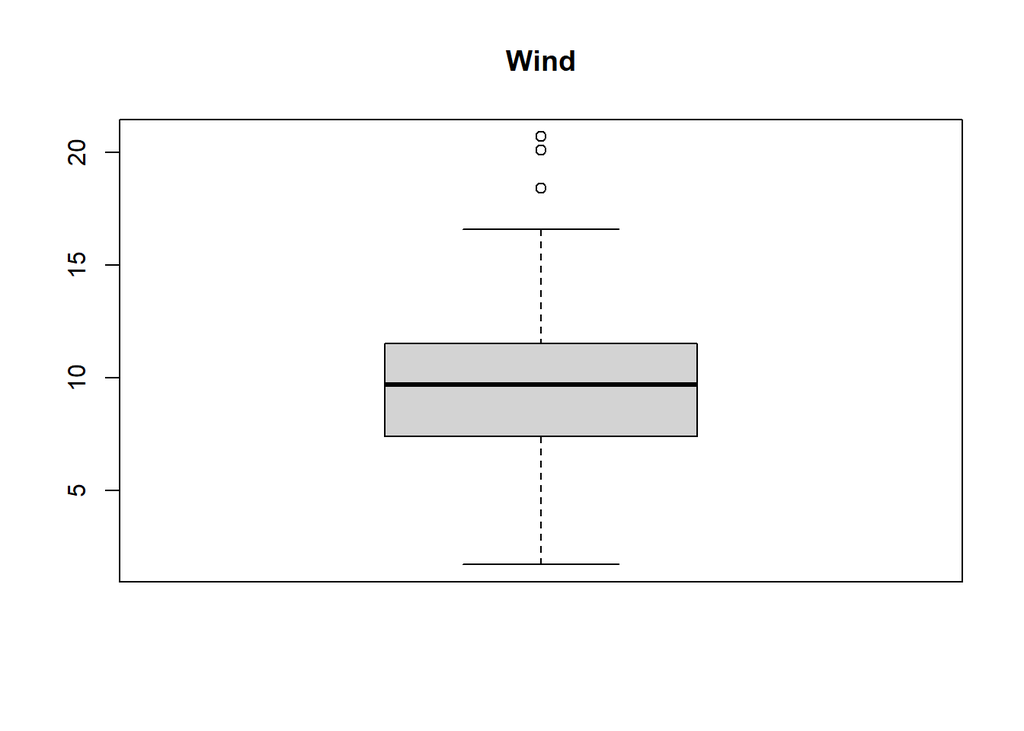

```r
#Wind boxplot followed by outliers

wind_plot<-boxplot(airquality$Wind, main = "Wind")
```

```r
wind_plot$out
```

```
## [1] 20.1 18.4 20.7
```

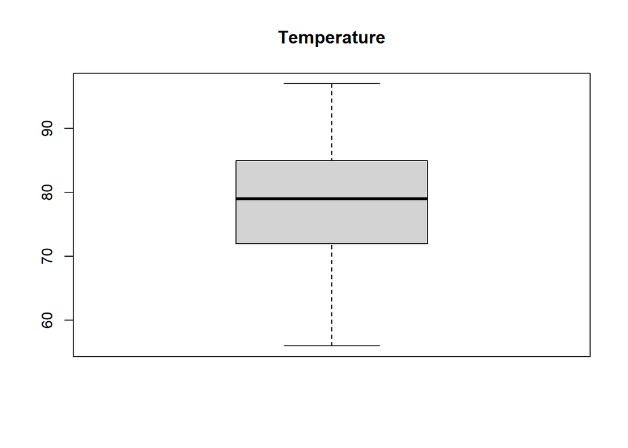

```r
#Temp boxplot followed by outliers
temp_plot<-boxplot(airquality$Temp, main = "Temperature")
```

```r
temp_plot$out
```

```
## numeric(0)
```

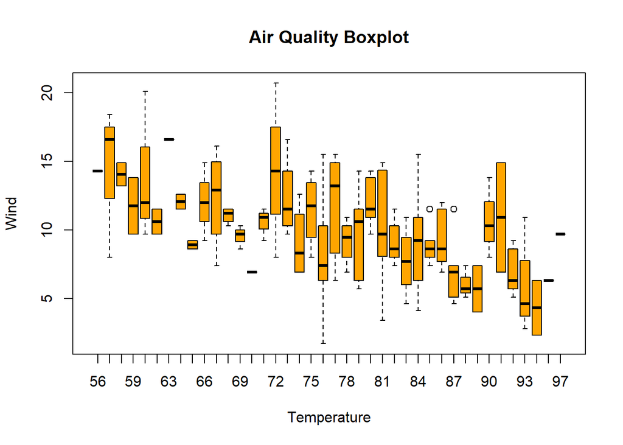

```r
#Wind / Temp boxplot followed by outliers
wind_temp_plot<-boxplot(formula = Wind ~ Temp, data = airquality, main = "Air Quality Boxplot", xlab= "Temperature", ylab= "Wind", col="orange")
```

```r
wind_temp_plot$out
```

```
## [1] 11.5 11.5
```

## Q3d (8 points)

Compute the upper quartile of the `Wind` variable with two different methods. HINT: Only show the upper quartile using indexing. For the type of quartile, please see https://www.rdocumentation.org/packages/stats/versions/3.6.2/topics/quantile.

```r
#Method 1
quantile(airquality$Wind, probs = c(0.75))
```

```
##  75%
## 11.5
```

```r
#Method 2
wind_2<-cbind(summary(airquality$Wind))
wind_2[5,]
```

```
## 3rd Qu.
##    11.5
```

```r
#Method 3
wind_1<-data.frame(quantile(airquality$Wind))
wind_1[4,]
```

```
## [1] 11.5
```

## Q3e (8 points)

Construct a pie chart to describe the number of entries by `Month`. HINT: use the `table()` function to count and tabulate the number of entries within a `Month`.

```r
#Tabulating number of entries in a month
month_entries<-table(airquality$Month, useNA="no")
month_entries
```

```
##
##  5  6  7  8  9
## 31 30 31 31 30
```

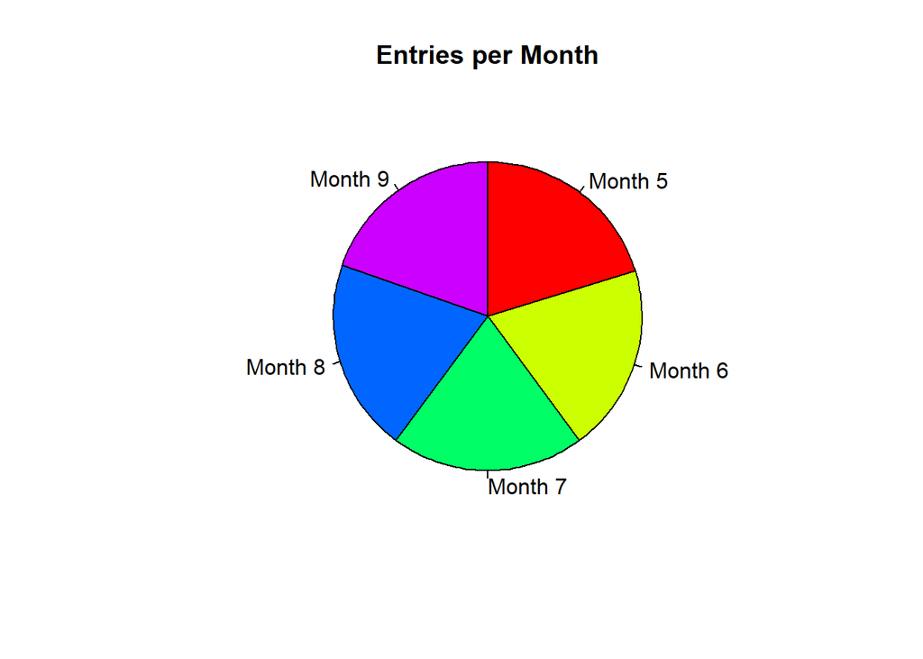

```r
#Create labels for pie chart
lbls <- c("Month 5", "Month 6", "Month 7", "Month 8", "Month 9")

#Create pie chart
pie(month_entries, labels = lbls, edges = 200, radius = 0.8, clockwise = TRUE, col=rainbow(length(month_entries)), main = "Entries per Month")
```

END of Assignment #1.